# CBM Concept Intervention Demo

This notebook demonstrates **concept intervention** on test cases, replicating `demo_intervention.py`.

**Key Concept**: When the model makes wrong concept predictions, we can **correct them manually** and see how it changes the final diagnosis. This is the main advantage of Concept Bottleneck Models!

**Test Cases:**

- Case 7: Non-Melanoma (BCC, 7-point score: 0)
- Case 596: Melanoma in situ (7-point score: 3)
- Case 578: Melanoma in situ (7-point score: 7)
- Case 657: Melanoma <0.76mm (7-point score: 8)

## 1. Setup and Imports

```python
import os
import sys
import torch
import numpy as np
from PIL import Image
from torchvision import transforms
import matplotlib.pyplot as plt

# Add parent directory to path
sys.path.insert(0, '..')

from src.models.basic_cbm import ConceptBottleneckModel
from src.utils.visualization import plot_intervention_analysis

print("✓ Imports successful")
print(f"PyTorch version: {torch.__version__}")
print(f"CUDA available: {torch.cuda.is_available()}")
```

```
✓ Imports successful
PyTorch version: 2.5.1
CUDA available: True
```

## 2. Load Trained Model

```python
# Load trained model
model_path = '../trained_models/derm7pt_best/best_model.pth'

if not os.path.exists(model_path):
    print(f"Error: Model not found at {model_path}")
else:
    print(f"Loading model from: {model_path}")
    model = ConceptBottleneckModel.load(model_path)
    model.eval()
    print("✓ Model loaded successfully")
```

```
Loading model from: ../trained_models/derm7pt_best/best_model.pth
```

```
✓ Model loaded successfully
```

## 3. Define Test Cases and Helper Functions

```python
# Test cases with ground truth concepts
cases = [
    {'case_num': 7, 'image': 'sample_data_derm7pt/case_007_dermoscopic.jpg', 'diagnosis': 'Non-Melanoma'},
    {'case_num': 596, 'image': 'sample_data_derm7pt/case_596_dermoscopic.jpg', 'diagnosis': 'Melanoma'},
    {'case_num': 578, 'image': 'sample_data_derm7pt/case_578_dermoscopic.jpg', 'diagnosis': 'Melanoma'},
    {'case_num': 657, 'image': 'sample_data_derm7pt/case_657_dermoscopic.jpg', 'diagnosis': 'Melanoma'}
]

# Ground truth concepts (from test set)
gt_concepts = {
    7: [0, 0, 1, 0, 0, 0, 0],      # Case 7: BCC, 7pt=0
    596: [2, 0, 0, 0, 1, 2, 0],    # Case 596: Melanoma in situ, 7pt=3
    578: [2, 1, 0, 2, 2, 2, 0],    # Case 578: Melanoma in situ, 7pt=7
    657: [2, 1, 0, 2, 2, 2, 1]     # Case 657: Melanoma < 0.76mm, 7pt=8
}

concept_names = [
    "Pigment Network", "Blue-Whitish Veil", "Vascular Structures",
    "Streaks", "Pigmentation", "Dots & Globules", "Regression"
]

class_labels = ['Absent', 'Regular', 'Irregular']

def preprocess_image(image_path):
    """Load and preprocess image."""
    transform = transforms.Compose([
        transforms.Resize((224, 224)),
        transforms.ToTensor(),
        transforms.Normalize(mean=[0.485, 0.456, 0.406], std=[0.229, 0.224, 0.225])
    ])

    image = Image.open(image_path).convert('RGB')
    image_tensor = transform(image).unsqueeze(0)

    viz_transform = transforms.Compose([
        transforms.Resize((224, 224)),
        transforms.ToTensor()
    ])
    image_viz = viz_transform(Image.open(image_path).convert('RGB'))
    image_viz = image_viz.permute(1, 2, 0).numpy()

    return image_tensor, image_viz

def intervene_on_concept(model, image_tensor, concept_idx, new_class):
    """Perform intervention on a specific concept."""
    with torch.no_grad():
        original_concepts, original_logits = model(image_tensor)
        concepts_reshaped = original_concepts.reshape(1, 7, 3)

        intervened_concepts = concepts_reshaped.clone()
        intervened_concepts[0, concept_idx, :] = 0.0
        intervened_concepts[0, concept_idx, new_class] = 1.0

        intervened_concepts_flat = intervened_concepts.reshape(1, -1)
        intervened_logits = model.task_predictor(intervened_concepts_flat)

        original_prob = torch.softmax(original_logits, dim=1)[0, 1].item()
        intervened_prob = torch.softmax(intervened_logits, dim=1)[0, 1].item()
        original_classes = concepts_reshaped.argmax(dim=2).squeeze().cpu().numpy()

    return original_classes, original_prob, intervened_prob

print(f"✓ Loaded {len(cases)} test cases")
print(f"✓ Helper functions defined")
```

```
✓ Loaded 4 test cases
✓ Helper functions defined
```

## 4. Run Intervention Analysis on All Cases

For each case, we:

1. Get original predictions
2. Test individual interventions (correct one wrong concept at a time to ground truth)
3. Test cumulative intervention (correct all wrong concepts simultaneously)
4. Create visualization showing impact of each intervention

```python
# Create output directory
output_dir = 'outputs'
os.makedirs(output_dir, exist_ok=True)

print("="*70)
print("Concept Intervention Analysis")
print("="*70)

# Process each case
for case in cases:
    case_num = case['case_num']
    image_path = case['image']
    ground_truth = case['diagnosis']

    print(f"\n{'='*70}")
    print(f"Case {case_num}: {ground_truth}")
    print(f"{'='*70}")

    if not os.path.exists(image_path):
        print(f"Warning: Image not found: {image_path}")
        continue

    # Load image
    image_tensor, image_viz = preprocess_image(image_path)

    # Get original prediction
    with torch.no_grad():
        original_concepts_tensor, original_logits = model(image_tensor)
        original_concepts = original_concepts_tensor.reshape(1, 7, 3).argmax(dim=2).squeeze().cpu().numpy()
        original_prob = torch.softmax(original_logits, dim=1)[0, 1].item()

    print(f"Original prediction: {original_prob:.1%} melanoma")

    # Get ground truth for this case
    case_gt_concepts = gt_concepts.get(case_num, [0]*7)

    # Find wrong concepts
    interventions_to_test = []
    for idx, (pred_class, gt_class, name) in enumerate(zip(original_concepts, case_gt_concepts, concept_names)):
        if pred_class != gt_class:
            interventions_to_test.append({
                'idx': idx,
                'name': name,
                'new_class': gt_class
            })

    print(f"Found {len(interventions_to_test)} wrong concept(s)")

    # Individual interventions
    interventions_data = []

    for interv in interventions_to_test:
        concept_idx = interv['idx']
        concept_name = interv['name']
        new_class = interv['new_class']

        orig_classes, orig_prob, interv_prob = intervene_on_concept(
            model, image_tensor, concept_idx, new_class
        )

        original_class = int(orig_classes[concept_idx])
        change = interv_prob - orig_prob
        crosses = (orig_prob < 0.5) != (interv_prob < 0.5)
        marker = "🔥" if crosses else ""

        interventions_data.append({
            'concept_name': concept_name,
            'concept_idx': concept_idx,
            'original_class': original_class,
            'new_class': new_class,
            'original_prob': orig_prob,
            'intervened_prob': interv_prob,
            'has_change': True
        })

        print(f"  {marker} {concept_name:.<25} {class_labels[original_class]:>10} → {class_labels[new_class]:<10} (GT) "
              f"| {orig_prob:.1%} → {interv_prob:.1%} ({change:+.1%})")

    # Cumulative intervention (all wrong concepts)
    if len(interventions_to_test) > 0:
        print(f"\n  Correcting ALL {len(interventions_to_test)} wrong concepts simultaneously:")

        with torch.no_grad():
            original_concepts_tensor, original_logits = model(image_tensor)
            concepts_reshaped = original_concepts_tensor.reshape(1, 7, 3)

            intervened_concepts = concepts_reshaped.clone()
            for interv in interventions_to_test:
                concept_idx = interv['idx']
                new_class = interv['new_class']
                intervened_concepts[0, concept_idx, :] = 0.0
                intervened_concepts[0, concept_idx, new_class] = 1.0

            intervened_concepts_flat = intervened_concepts.reshape(1, -1)
            intervened_logits = model.task_predictor(intervened_concepts_flat)

            cumulative_prob = torch.softmax(intervened_logits, dim=1)[0, 1].item()

        change = cumulative_prob - original_prob
        crosses = (original_prob < 0.5) != (cumulative_prob < 0.5)
        marker = "🔥" if crosses else ""

        print(f"  {marker} ALL CONCEPTS CORRECTED........ "
              f"| {original_prob:.1%} → {cumulative_prob:.1%} ({change:+.1%})")

        # Add cumulative intervention to data
        interventions_data.append({
            'concept_name': f'ALL {len(interventions_to_test)} CORRECTED',
            'concept_idx': -1,
            'original_class': -1,
            'new_class': -1,
            'original_prob': original_prob,
            'intervened_prob': cumulative_prob,
            'has_change': True
        })

    # Create visualization
    fig = plot_intervention_analysis(
        image=image_viz,
        case_num=case_num,
        ground_truth=ground_truth,
        interventions_data=interventions_data,
        concept_names=concept_names,
        original_prob=original_prob,
        original_concepts=original_concepts
    )

    if fig is not None:
        output_path = os.path.join(output_dir, f'intervention_case_{case_num}.png')
        fig.savefig(output_path, dpi=150, bbox_inches='tight', facecolor='white')
        plt.close(fig)
        print(f"\n✓ Saved: {output_path}")

print("\n" + "="*70)
print("✅ All intervention analyses complete!")
print("="*70)
```

```
======================================================================
Concept Intervention Analysis
======================================================================

======================================================================
Case 7: Non-Melanoma
======================================================================
Original prediction: 37.8% melanoma
Found 2 wrong concept(s)
   Vascular Structures......     Absent → Regular    (GT) | 37.8% → 37.6% (-0.2%)
  🔥 Dots & Globules..........  Irregular → Absent     (GT) | 37.8% → 54.2% (+16.4%)

  Correcting ALL 2 wrong concepts simultaneously:
  🔥 ALL CONCEPTS CORRECTED........ | 37.8% → 54.0% (+16.2%)
```

```
✓ Saved: outputs/intervention_case_7.png

======================================================================
Case 596: Melanoma
======================================================================
Original prediction: 37.8% melanoma
Found 2 wrong concept(s)
  🔥 Pigment Network..........     Absent → Irregular  (GT) | 37.8% → 52.2% (+14.4%)
   Pigmentation.............     Absent → Regular    (GT) | 37.8% → 36.1% (-1.7%)

  Correcting ALL 2 wrong concepts simultaneously:
  🔥 ALL CONCEPTS CORRECTED........ | 37.8% → 50.4% (+12.6%)
```

```
✓ Saved: outputs/intervention_case_596.png

======================================================================
Case 578: Melanoma
======================================================================
Original prediction: 34.5% melanoma
Found 3 wrong concept(s)
   Pigment Network..........     Absent → Irregular  (GT) | 34.5% → 48.7% (+14.2%)
   Blue-Whitish Veil........     Absent → Regular    (GT) | 34.5% → 43.9% (+9.4%)
   Streaks..................     Absent → Irregular  (GT) | 34.5% → 44.4% (+9.9%)

  Correcting ALL 3 wrong concepts simultaneously:
  🔥 ALL CONCEPTS CORRECTED........ | 34.5% → 68.1% (+33.6%)
```

```
✓ Saved: outputs/intervention_case_578.png

======================================================================
Case 657: Melanoma
======================================================================
Original prediction: 34.5% melanoma
Found 4 wrong concept(s)
   Pigment Network..........     Absent → Irregular  (GT) | 34.5% → 48.7% (+14.2%)
   Blue-Whitish Veil........     Absent → Regular    (GT) | 34.5% → 43.9% (+9.4%)
   Streaks..................     Absent → Irregular  (GT) | 34.5% → 44.4% (+9.9%)
   Regression...............     Absent → Regular    (GT) | 34.5% → 31.0% (-3.5%)

  Correcting ALL 4 wrong concepts simultaneously:
  🔥 ALL CONCEPTS CORRECTED........ | 34.5% → 64.5% (+30.0%)
```

```
✓ Saved: outputs/intervention_case_657.png

======================================================================
✅ All intervention analyses complete!
======================================================================
```

## 5. Display Intervention Visualizations

View all generated intervention analysis plots.

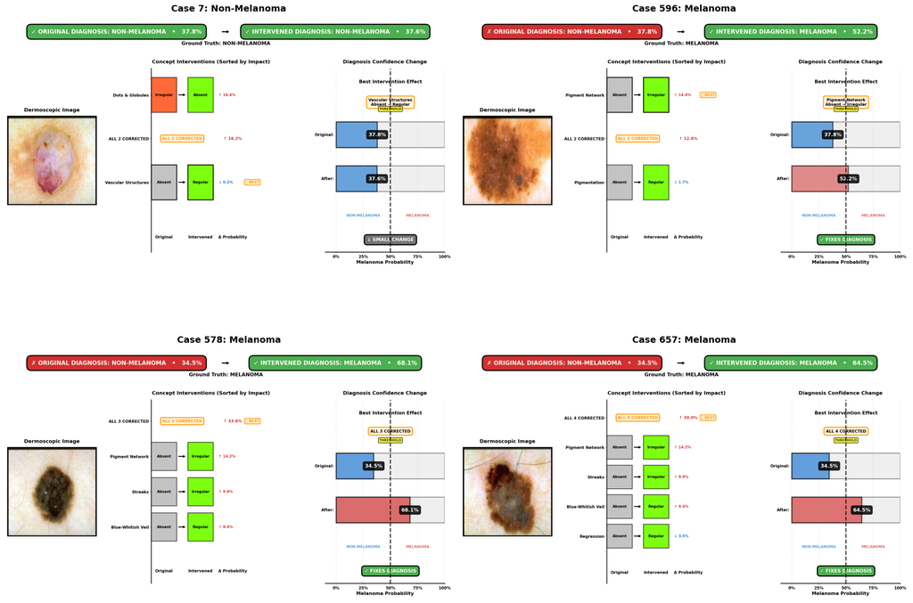

```
✓ Intervention visualizations displayed
```

```python
# Display all intervention visualizations
fig, axes = plt.subplots(2, 2, figsize=(20, 16))
axes = axes.flatten()

for idx, case in enumerate(cases):
    output_path = os.path.join(output_dir, f'intervention_case_{case["case_num"]}.png')
    if os.path.exists(output_path):
        img = plt.imread(output_path)
        axes[idx].imshow(img)
        axes[idx].axis('off')
        axes[idx].set_title(f'Case {case["case_num"]}: {case["diagnosis"]}', fontsize=14, fontweight='bold')

plt.tight_layout()
plt.show()

print("✓ Intervention visualizations displayed")
```

## 6. Understanding the Results

**What the visualizations show:**

**Key Observations:**

- **Individual interventions** correct one concept at a time to ground truth
- **Cumulative intervention** corrects all wrong concepts simultaneously
- Some concepts have **large impact** on diagnosis (move probability significantly)
- Some concepts have **minimal impact** (probability barely changes)
- When intervention **crosses 0.5 threshold**, it changes the diagnosis (Non-Melanoma ↔ Melanoma)

**Why this matters:**

1. **Clinician collaboration**: Doctors can correct wrong concepts they disagree with
2. **Trust and transparency**: See exactly how each feature affects the diagnosis
3. **Model debugging**: Identify which concepts the model relies on most
4. **Concept quality assessment**: Concepts with large intervention impact are more important

## 7. Summary

**What we demonstrated:**

1. ✅ **Concept Intervention**: Correcting wrong concepts to ground truth values
2. ✅ **Individual Interventions**: One concept at a time (shows per-concept impact)
3. ✅ **Cumulative Intervention**: All wrong concepts corrected simultaneously
4. ✅ **Impact Quantification**: Exact change in melanoma probability for each intervention
5. ✅ **Enhanced Visualizations**: Publication-quality figures showing intervention effects

**Key Findings:**

- Different concepts have different levels of influence on the final diagnosis
- Some interventions can flip the diagnosis (cross 0.5 threshold) 🔥
- Cumulative intervention shows combined effect of correcting all concepts
- Intervention reveals which concepts the model relies on most

**Comparison with Prediction Demo:**

- **Prediction demo** (`02_demo_with_sample_data.ipynb`): Shows what the model predicts
- **Intervention demo** (this notebook): Shows how predictions change when concepts are corrected

**Next Steps:**

1. **Full test set analysis**: Run `examples/intervention_analysis.py` for comprehensive metrics
2. **Quantitative evaluation**: See `outputs/intervention_analysis/*.csv` for statistical summaries
3. **Research paper**: Use these visualizations and metrics to demonstrate CBM interpretability

```python
print("✅ Intervention demo complete!")
print("\nGenerated files:")
for case in cases:
    output_path = f"outputs/intervention_case_{case['case_num']}.png"
    if os.path.exists(output_path):
        print(f"  - {output_path}")

print("\nNext:")
print("  - Compare with prediction demo: outputs/demo_case_*.png")
print("  - Run full test set analysis: python examples/intervention_analysis.py")
print("  - Check comprehensive metrics: outputs/intervention_analysis/*.csv")
```

```
✅ Intervention demo complete!

Generated files:
  - outputs/intervention_case_7.png
  - outputs/intervention_case_596.png
  - outputs/intervention_case_578.png
  - outputs/intervention_case_657.png

Next:
  - Compare with prediction demo: outputs/demo_case_*.png
  - Run full test set analysis: python examples/intervention_analysis.py
  - Check comprehensive metrics: outputs/intervention_analysis/*.csv
```